# 中垂線、角平分線與最短路徑綜合

> 來源整理：改國二下7_三角形的邊角關係_易讀版.md

## 角平分線交點與路徑長短比較

> 學習目標：角平分線交於同一點時，可把原三角形的邊角大小轉成到交點的距離大小。

### 先抓住核心

- 若三角形三邊有大小順序，可先轉成三角形三角的大小順序。
- 角平分線會把角分成兩半，因此角的大小順序會保留在半角中。
- 在包含交點 I 的小三角形中，可再次使用大角對大邊。
- 原講義例子中可得到 IB > IA > IC，所以從 C 出發到 I 最短。
- 這類題目需要連續轉換：邊長順序 -> 角度順序 -> 小三角形邊長順序。

### 解題流程

1. 先由原三角形邊長比較原角大小。
2. 利用角平分線，把角度大小轉成半角大小。
3. 在小三角形中用大角對大邊比較到 I 的距離。
4. 距離最短者，在速度相同時最先到達。

### 公式、性質與判斷

- **半角**：角平分線會保留角大小順序。
- **路徑比較**：同速時，距離越短越早到。
- **常見結論**：若 IB>IA>IC，則 C 到 I 最短。

### 例題拆解

- 若 AB>BC>AC，先得到對角 ∠C>∠A>∠B。
- 角平分後可比較小三角形中的角，再比較 IA、IB、IC。
- 若 IB>IA>IC，則從 C 出發的螞蟻先到 I。

### 易錯提醒

- 只用原三角形邊長直接比較 IA、IB、IC，少了中間推理。
- 忘記速度相同時，路程短才先到。

### 小練一下

- 角平分線會不會改變角度大小順序？
- 同速前進時，距離長短和到達時間有什麼關係？

### 記憶鉤子

- 這題像三段翻譯：邊翻角，角平分翻半角，小三角形再翻邊。
- 不要一看到 I 就急著比較線段，先回原三角形找邊角關係。

### 圖像化理解

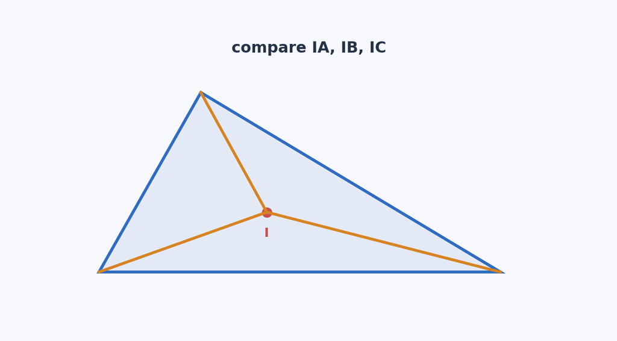

角平分線交點與路徑長短比較

圖解：示意三條角平分線交於 I，並比較 IA、IB、IC 的長短。

## 反射最短路徑與三角形不等式

> 學習目標：在直線上找一點讓 PA+PB 最小，常用反射把折線變成直線。

### 先抓住核心

- 若 P 在某條直線上，想讓 PA+PB 最小，可把 A 對該直線反射到 C。
- 因為 P 在對稱軸上，所以 PA=PC。
- 因此 PA+PB = PC+PB。
- 當 C、P、B 共線時，PC+PB 等於 CB，最短。
- 其他點 P’ 形成三角形，P’C+P’B 會大於 CB。

### 解題流程

1. 把其中一點對指定直線反射。
2. 連接反射點與另一點。
3. 交指定直線的點就是最短路徑點 P。
4. 最小值等於反射點到另一點的直線距離。

### 公式、性質與判斷

- **反射等距**：若 P 在對稱軸上，PA=PC。
- **最短路徑**：PA+PB 的最小值 = CB。
- **理由**：三角形兩邊和大於第三邊。

### 例題拆解

- A(-3,3) 對 x 軸反射為 C(-3,-3)。
- 連接 C(-3,-3) 與 B(5,12)，交 x 軸的點就是最短路徑點。
- 最小值等於 CB，可用距離公式計算。

### 易錯提醒

- 反射錯點，導致最短路徑線畫錯。
- 找到交點 P 後，仍用 PA+PB 分別算，忘記可直接用 CB。

### 小練一下

- 為什麼 P 在 x 軸上時 PA=PC？
- 最短路徑最後會變成折線還是直線？

### 記憶鉤子

- 反射法的魔法：把折線 PA+PB 變成直線 PC+PB。
- 最短不是猜出來，是由三角形兩邊和大於第三邊保證。

### 圖像化理解

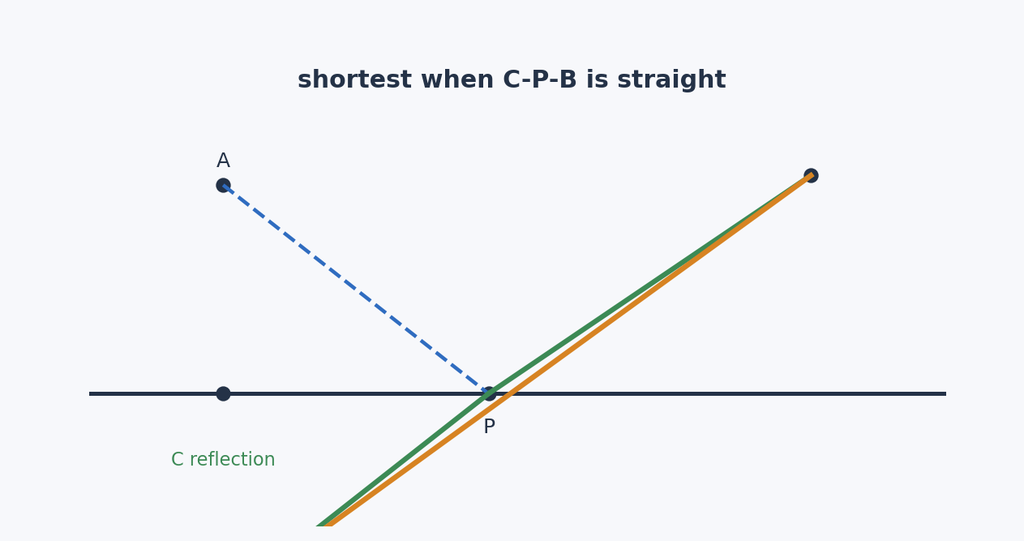

反射最短路徑與三角形不等式

圖解：用反射點 C 與直線 CB 示意最短路徑。

## 格線、全等與角度總和

> 學習目標：格線角度題常用全等或對稱，把成對角補成 90° 或 45°。

### 先抓住核心

- 在正方形格線中，旋轉或對稱常能製造全等三角形。
- 全等後可把某些角轉換成另一個位置的角。
- 有些角成對相加會變成 90°。
- 正方形對角線常帶出 45°。
- 總和題可先分組，再把每組固定角度相加。

### 解題流程

1. 找出格線中的全等三角形。
2. 把對應角移到同一個直角附近。
3. 將角分組，例如兩角一組為 90°。
4. 剩下對角線角常為 45°。
5. 把各組角度加總。

### 公式、性質與判斷

- **直角組**：兩角常可組成 90°。
- **正方形對角線**：常出現 45°。
- **例**：3*90° + 3*45° = 405°。

### 例題拆解

- 3×3 格線題中，可把角分成三組 90° 與三個 45°。
- 因此角 1 到角 9 的總和可得 405°。
- 全等三角形可把看似不同的角搬到直角附近比較。

### 易錯提醒

- 用目測角度代替全等或對稱理由。
- 沒有分組就硬加，容易漏角或重複。

### 小練一下

- 正方形對角線和邊形成幾度？
- 若有三組角各為 90°，總共是多少？

### 記憶鉤子

- 格線角度題不要逐個量，先找全等和互補組。
- 正方形藏著很多 90° 和 45°。

### 圖像化理解

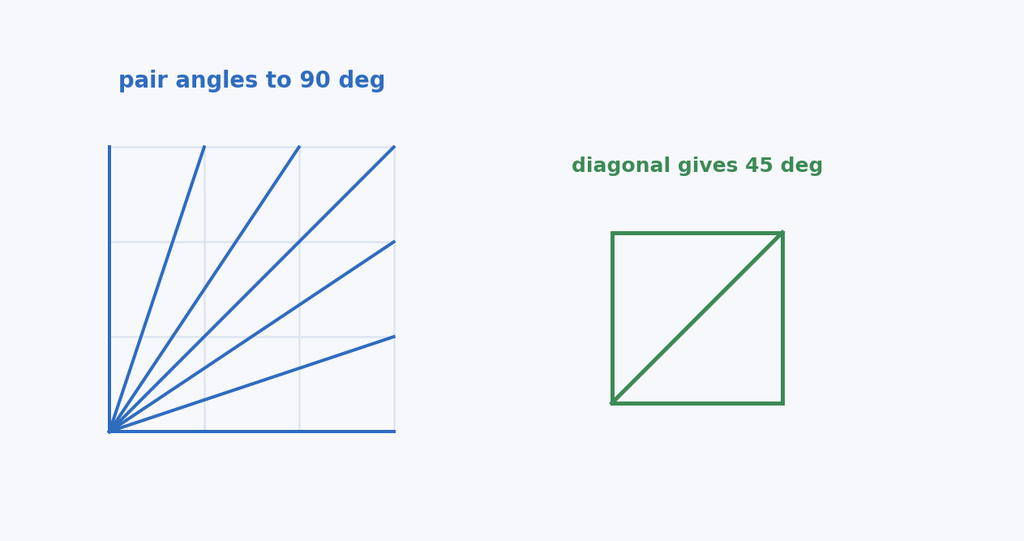

格線、全等與角度總和

圖解：用 3×3 格線示意角度配對成 90° 與 45°。

## 摺疊、中垂線與角度

> 學習目標：摺疊題會產生等長與等角；中垂線會產生直角與到兩端點等距。

### 先抓住核心

- 摺疊後重合的點、邊、角會對應相等。
- 若 AC 是 DE 的中垂線，則 AC 垂直 DE，且 AC 上的點到 D、E 距離相等。
- 等腰三角形可由兩邊相等推出底角相等。
- 角度題常先求等腰三角形的底角，再用 180° 扣掉。
- 中垂線給出的 90° 常是最後求角的關鍵。

### 解題流程

1. 標出摺疊造成的等邊與等角。
2. 標出中垂線造成的直角。
3. 用等腰三角形求底角。
4. 用三角形內角和求目標角。

### 公式、性質與判斷

- **摺疊**：重合部分相等。
- **中垂線**：垂直且等距。
- **等腰**：兩底角相等。

### 例題拆解

- 若 ∠B=60° 且 AB=AE，則 △ABE 為等腰，∠AEB=60°。
- 若 AC 是 DE 的中垂線，則 ∠EFC=90°。
- 若 ∠CEF=60°，則 ∠C=180°-90°-60°=30°。
- 若 ∠B=50°，等腰底角可得 65°，最後 ∠C=40°。

### 易錯提醒

- 只用摺疊等長，忘記中垂線還有垂直。
- 等腰三角形底角位置標錯。

### 小練一下

- 中垂線會給出哪兩種資訊？
- 等腰三角形的兩底角有什麼關係？

### 記憶鉤子

- 摺疊給相等，中垂線給 90°，等腰給底角相等。
- 這類題是三個工具串起來，不是單一公式。

### 圖像化理解

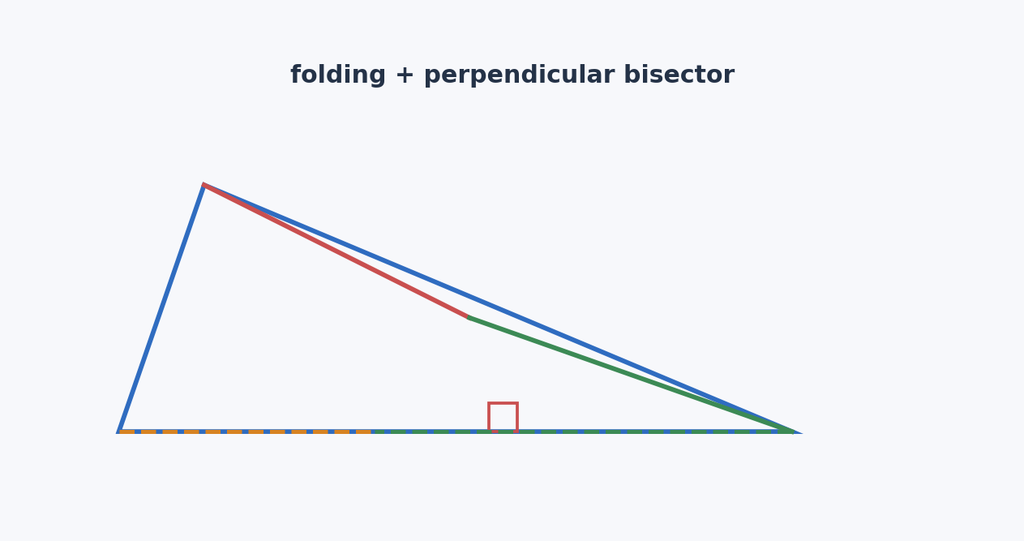

摺疊、中垂線與角度

圖解：示意摺疊點與中垂線形成直角，再求目標角。

## 角平分線、點到邊距離與面積

> 學習目標：角平分線上的點到角兩邊距離相等，這能直接轉成三角形面積。

### 先抓住核心

- 角平分線上的點到角兩邊的距離相等。
- 若 BP 是 ∠B 的角平分線，且 PA 垂直 BA、PD 垂直 BC，則 PA=PD。
- 求 △BPC 面積時，可把 BC 當底，PD 當高。
- 角度部分先用三角形內角和求 ∠B，再取半角。
- 面積最後用底*高/2。

### 解題流程

1. 先用內角和求 ∠B。
2. 因 BP 是角平分線，求出 ∠PBC。
3. 用三角形 BPC 內角和求 ∠BPC。
4. 由角平分線距離性質得 PA=PD。
5. 用 BC*PD/2 求面積。

### 公式、性質與判斷

- **角平分線距離**：角平分線上一點到兩邊距離相等。
- **三角形面積**：Area=base*height/2。
- **例**：18*5/2=45。

### 例題拆解

- 若 ∠A=90°、∠C=36°，則 ∠B=54°。
- 若 BP 平分 ∠B，則 ∠PBC=27°。
- ∠BPC=180°-27°-36°=117°。
- 若 PA=5，則 PD=5，△BPC 面積為 18*5/2=45。

### 易錯提醒

- 把角平分線性質誤認成到兩頂點距離相等。
- 面積用到的高沒有確認垂直。

### 小練一下

- 角平分線上的點到角兩邊距離有什麼關係？
- 底 18、高 5 的三角形面積是多少？

### 記憶鉤子

- 角平分線不只平分角，還能給等距。
- 面積題找到高，就已經解了一半。

### 圖像化理解

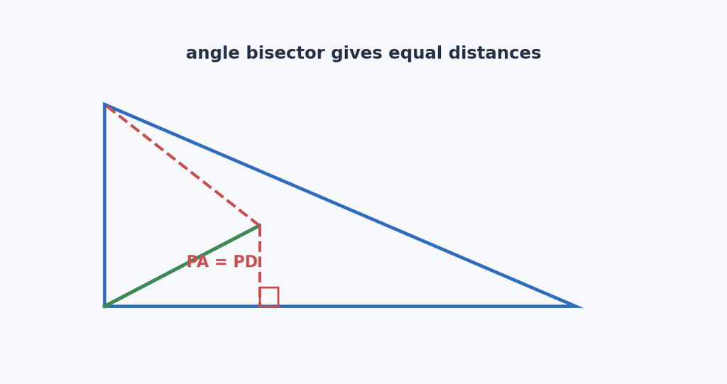

角平分線、點到邊距離與面積

圖解：示意角平分線上一點到兩邊距離相等，並用作面積的高。

## 平行四邊形與多角綜合

> 學習目標：平行四邊形綜合題通常先找對角相等、鄰角互補，再用四邊形角和收尾。

### 先抓住核心

- 平行四邊形的對角相等。
- 平行四邊形的鄰角互補。
- 若兩個平行四邊形交疊，先把可轉換的角全部標出。
- 四邊形內角和是 360°。
- 綜合題常把已知的 60°、70°、80° 轉成相鄰補角後，再用角和求目標角。

### 解題流程

1. 標出平行四邊形的對角相等。
2. 用 180° 減已知角求鄰角。
3. 找出需要加總的四邊形或多邊形。
4. 用 360° 或 180° 收尾。

### 公式、性質與判斷

- **平行四邊形**：對角相等，鄰角互補。
- **四邊形內角和**：360°。
- **例**：360° - 80° - 120° - 110° = 50°。

### 例題拆解

- 若 ∠1=60°，則相鄰補角是 120°。
- 若 ∠2=70°，則相鄰補角是 110°。
- 若另一角為 80°，目標角可由 360°-80°-120°-110°=50° 求得。

### 易錯提醒

- 把鄰角誤當相等，忘記它們互補。
- 沒有看清楚要用哪個四邊形的 360°。

### 小練一下

- 平行四邊形的鄰角和是多少？
- 四邊形內角和是多少？

### 記憶鉤子

- 平行四邊形題先找對角和鄰角，再用角和。
- 多圖形交疊時，角度先搬到同一個四邊形裡。

### 圖像化理解

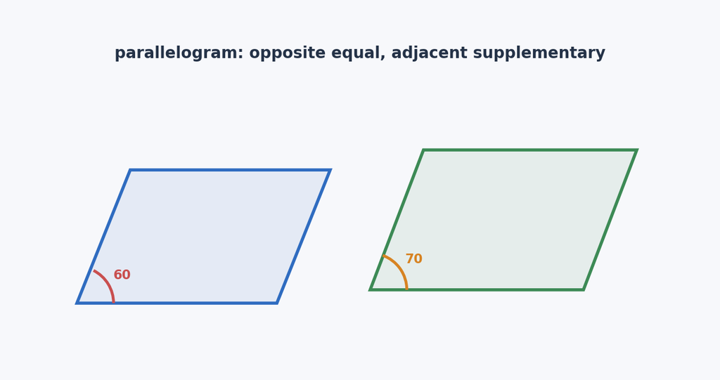

平行四邊形與多角綜合